# Region/Polviews/Religion

2024-10-05

## Years for each variable

```r
data(gss_all)
```

Region

```r
gss_which_years(gss_all, region)
```

```
## # A tibble: 34 × 2
##    year      region
##    <dbl+lbl> <lgl>
##  1 1972      TRUE
##  2 1973      TRUE
##  3 1974      TRUE
##  4 1975      TRUE
##  5 1976      TRUE
##  6 1977      TRUE
##  7 1978      TRUE
##  8 1980      TRUE
##  9 1982      TRUE
## 10 1983      TRUE
## # ℹ 24 more rows
```

```r
gss_which_years(gss_all, sex)
```

```
## # A tibble: 34 × 2
##    year      sex
##    <dbl+lbl> <lgl>
##  1 1972      TRUE
##  2 1973      TRUE
##  3 1974      TRUE
##  4 1975      TRUE
##  5 1976      TRUE
##  6 1977      TRUE
##  7 1978      TRUE
##  8 1980      TRUE
##  9 1982      TRUE
## 10 1983      TRUE
## # ℹ 24 more rows
```

```r
gss_which_years(gss_all, race)
```

```
## # A tibble: 34 × 2
##    year      race
##    <dbl+lbl> <lgl>
##  1 1972      TRUE
##  2 1973      TRUE
##  3 1974      TRUE
##  4 1975      TRUE
##  5 1976      TRUE
##  6 1977      TRUE
##  7 1978      TRUE
##  8 1980      TRUE
##  9 1982      TRUE
## 10 1983      TRUE
## # ℹ 24 more rows
```

```r
gss_which_years(gss_all, age)
```

```
## # A tibble: 34 × 2
##    year      age
##    <dbl+lbl> <lgl>
##  1 1972      TRUE
##  2 1973      TRUE
##  3 1974      TRUE
##  4 1975      TRUE
##  5 1976      TRUE
##  6 1977      TRUE
##  7 1978      TRUE
##  8 1980      TRUE
##  9 1982      TRUE
## 10 1983      TRUE
## # ℹ 24 more rows
```

```r
gss_which_years(gss_all, educ)
```

```
## # A tibble: 34 × 2
##    year      educ
##    <dbl+lbl> <lgl>
##  1 1972      TRUE
##  2 1973      TRUE
##  3 1974      TRUE
##  4 1975      TRUE
##  5 1976      TRUE
##  6 1977      TRUE
##  7 1978      TRUE
##  8 1980      TRUE
##  9 1982      TRUE
## 10 1983      TRUE
## # ℹ 24 more rows
```

```r
gss_which_years(gss_all, income)
```

```
## # A tibble: 34 × 2
##    year      income
##    <dbl+lbl> <lgl>
##  1 1972      FALSE
##  2 1973      TRUE
##  3 1974      TRUE
##  4 1975      TRUE
##  5 1976      TRUE
##  6 1977      TRUE
##  7 1978      TRUE
##  8 1980      TRUE
##  9 1982      TRUE
## 10 1983      TRUE
## # ℹ 24 more rows
```

Polviews - Think of self as liberal or conservative

```r
gss_which_years(gss_all, polviews)
```

```
## # A tibble: 34 × 2
##    year      polviews
##    <dbl+lbl> <lgl>
##  1 1972      FALSE
##  2 1973      FALSE
##  3 1974      TRUE
##  4 1975      TRUE
##  5 1976      TRUE
##  6 1977      TRUE
##  7 1978      TRUE
##  8 1980      TRUE
##  9 1982      TRUE
## 10 1983      TRUE
## # ℹ 24 more rows
```

Religion - R’s religious preference

```r
gss_which_years(gss_all, relig)
```

```
## # A tibble: 34 × 2
##    year      relig
##    <dbl+lbl> <lgl>
##  1 1972      TRUE
##  2 1973      TRUE
##  3 1974      TRUE
##  4 1975      TRUE
##  5 1976      TRUE
##  6 1977      TRUE
##  7 1978      TRUE
##  8 1980      TRUE
##  9 1982      TRUE
## 10 1983      TRUE
## # ℹ 24 more rows
```

```r
y74 <- gss_get_yr(1974)
```

```
## Fetching: https://gss.norc.org/documents/stata/1974_stata.zip
```

```r
y74_f <- y74[c('region', 'polviews', 'relig')]
y74_f$region <- factor(y74_f$region, levels = c(1, 2, 3, 4, 5, 6, 7, 8, 9), labels = c("new england", "middle atlantic", "east north central", "west north central", "south atlantic", "east south atlantic", "west south central", "mountain", "pacific"))
str(y74_f)
```

```
## tibble [1,484 × 3] (S3: tbl_df/tbl/data.frame)
##  $ region  : Factor w/ 9 levels "new england",..: 6 6 6 6 6 6 6 6 6 6 ...
##  $ polviews: dbl+lbl [1:1484]     4,     5,     6,     6,     6,     5,     5,     ...
##    ..@ label       : chr "think of self as liberal or conservative"
##    ..@ format.stata: chr "%29.0g"
##    ..@ labels      : Named num [1:20] 1 2 3 4 5 6 7 NA NA NA ...
##    .. ..- attr(*, "names")= chr [1:20] "extremely liberal" "liberal" "slightly liberal" "moderate, middle of the road" ...
##  $ relig   : dbl+lbl [1:1484] 1, 1, 1, 1, 1, 1, 1, 1, 1, 1, 1, 1, 1, 1, 1, 1, 1, 1,...
##    ..@ label       : chr "r's religious preference"
##    ..@ format.stata: chr "%29.0g"
##    ..@ labels      : Named num [1:26] 1 2 3 4 5 6 7 8 9 10 ...
##    .. ..- attr(*, "names")= chr [1:26] "protestant" "catholic" "jewish" "none" ...
```

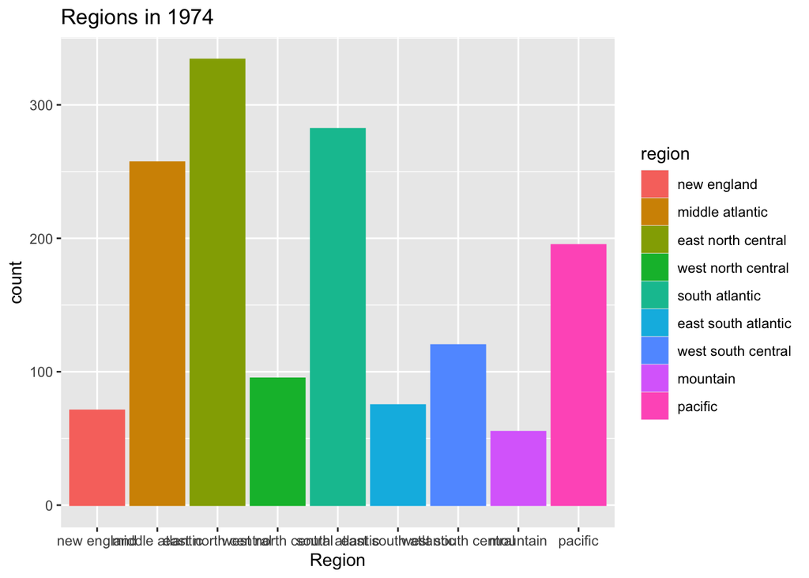

```r
plot74 <- ggplot(y74_f, aes(x=region, color=region, fill=region)) + geom_histogram(stat="count") + labs(title = "Regions in 1974", x="Region")
plot74
```

```r
y18 <- gss_get_yr(2018)
```

```
## Fetching: https://gss.norc.org/documents/stata/2018_stata.zip
```

```r
y18_f <- y18[c('region', 'polviews', 'relig')]
y18_f$region <- factor(y18_f$region, levels = c(1, 2, 3, 4, 5, 6, 7, 8, 9), labels = c("new england", "middle atlantic", "east north central", "west north central", "south atlantic", "east south atlantic", "west south central", "mountain", "pacific"))
str(y18_f)
```

```
## tibble [2,348 × 3] (S3: tbl_df/tbl/data.frame)
##  $ region  : Factor w/ 9 levels "new england",..: 1 1 1 1 1 1 2 2 2 1 ...
##  $ polviews: dbl+lbl [1:2348]     6, NA(d),     5,     4,     7,     3,     4,     ...
##    ..@ label       : chr "think of self as liberal or conservative"
##    ..@ format.stata: chr "%29.0g"
##    ..@ labels      : Named num [1:20] 1 2 3 4 5 6 7 NA NA NA ...
##    .. ..- attr(*, "names")= chr [1:20] "extremely liberal" "liberal" "slightly liberal" "moderate, middle of the road" ...
##  $ relig   : dbl+lbl [1:2348] 11,  2,  4,  1,  2,  2,  1,  2,  4,  1,  2,  1,  2,  ...
##    ..@ label       : chr "r's religious preference"
##    ..@ format.stata: chr "%29.0g"
##    ..@ labels      : Named num [1:26] 1 2 3 4 5 6 7 8 9 10 ...
##    .. ..- attr(*, "names")= chr [1:26] "protestant" "catholic" "jewish" "none" ...
```

```r
#plot18 <- ggplot(y18_f, aes(x=region)) + geom_qq() + labs(title = "Regions in 2018", x="Region")
#plot18
```

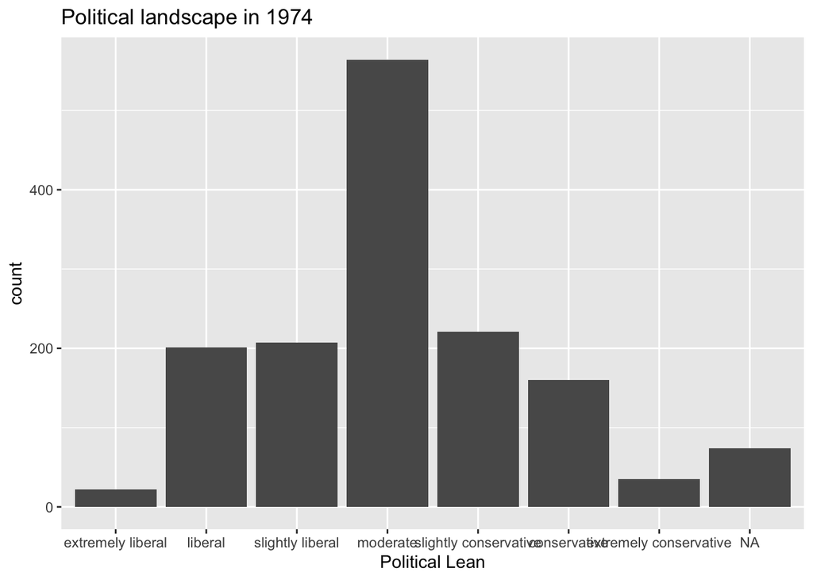

```r
y74_f$polviews <- factor(y74_f$polviews, levels = c(1, 2, 3, 4, 5, 6, 7), labels = c("extremely liberal", "liberal", "slightly liberal", "moderate", "slightly conservative", "conservative", "extremely conservative"))

y18_f$polviews <- factor(y18_f$polviews, levels = c(1, 2, 3, 4, 5, 6, 7), labels = c("extremely liberal", "liberal", "slightly liberal", "moderate", "slightly conservative", "conservative", "extremely conservative"))

plot74 <- ggplot(y74_f, aes(x=polviews)) + geom_histogram(stat="count") + labs(title = "Political landscape in 1974", x="Political Lean")
plot74
```

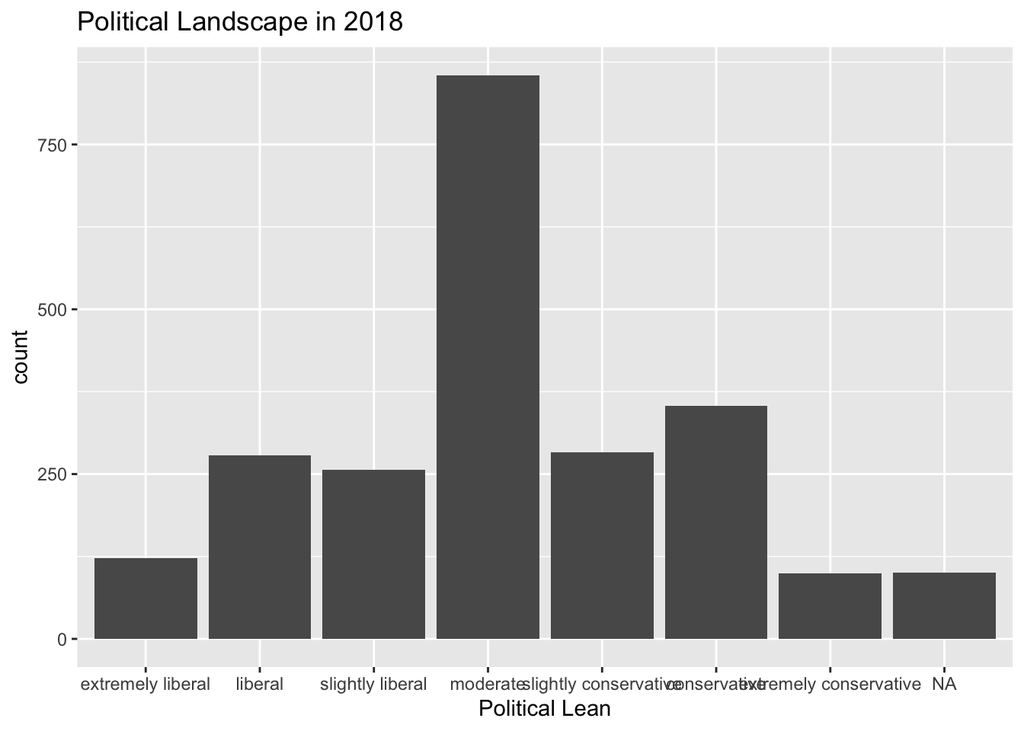

```r
plot18 <- ggplot(y18_f, aes(x=polviews)) + geom_histogram(stat="count") + labs(title = "Political Landscape in 2018", x="Political Lean")
plot18
```

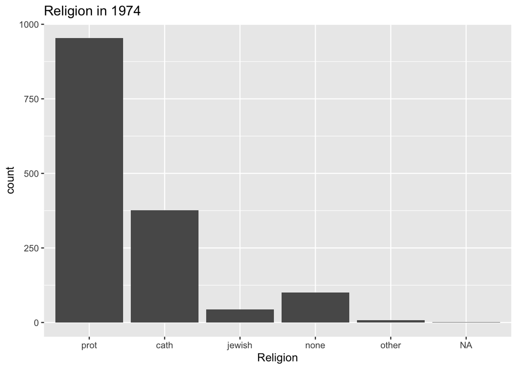

```r
y74_f$relig <- factor(y74_f$relig, levels = c(1, 2, 3, 4, 5, 6, 7, 8, 9, 10, 11, 12, 13), labels = c("prot", "cath", "jewish", "none", "other", "bud", "hind", "eastern", "islam", "ortho", "chris", "native", "nonden"))

#y18_f$relig <- factor(y18_f$relig, levels = c(1, 2, 3, 4, 5, 6, 7, 8, 9, 10, 11, 12, 13))

y18_f$relig <- case_when(
  y18_f$relig == 1 ~ 'Protestant',
  y18_f$relig == 2 ~ 'Catholic',
  y18_f$relig == 3 ~ 'Jewish',
  y18_f$relig == 4 ~ 'None',
  y18_f$relig == 5 ~ 'Other',
  y18_f$relig == 6 ~ 'Other',
  y18_f$relig == 7 ~ 'Other',
  y18_f$relig == 8 ~ 'Other',
  y18_f$relig == 9 ~ 'Other',
  y18_f$relig == 10 ~ 'Christian',
  y18_f$relig == 11 ~ 'Christian',
  y18_f$relig == 12 ~ 'Other',
  y18_f$relig == 13 ~ 'Christian',
  TRUE ~ 'NA'
)

plot74 <- ggplot(y74_f, aes(x=relig)) + geom_histogram(stat="count") + labs(title = "Religion in 1974", x="Religion")
plot74
```

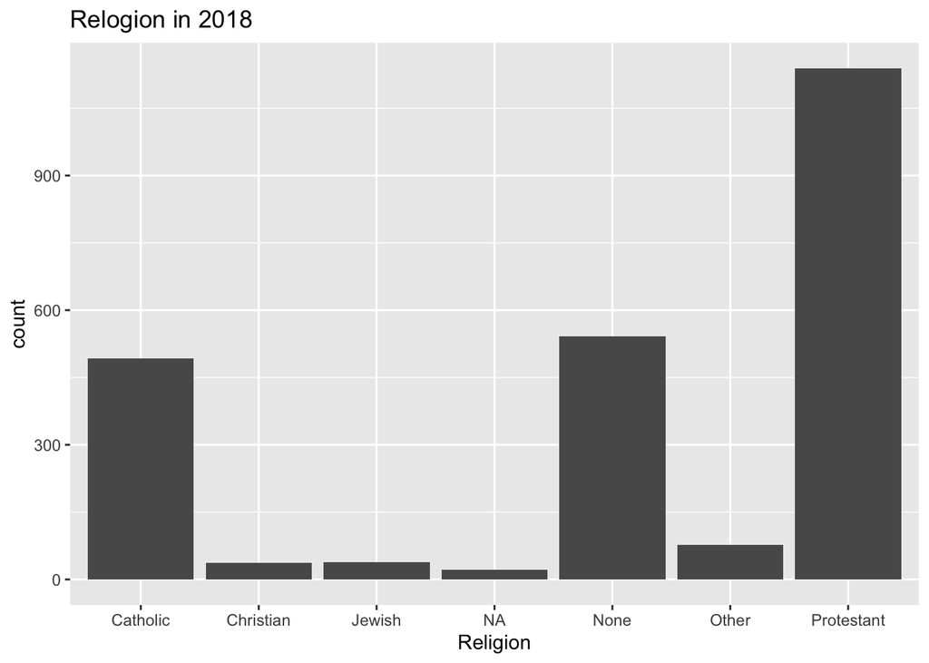

```r
plot18 <- ggplot(y18_f, aes(x=relig)) + geom_histogram(stat="count") + labs(title = "Relogion in 2018", x="Religion")
plot18
```

```r
vars <- c('X', 'year', 'id', 'sex', 'age', 'race', 'relig', 'educ', 'income', 'region', 'polviews')
gss_old <- read.csv("../Marissa/gss_old.csv")
gss_old <- gss_old[, vars]
gss_new <- read.csv("../Marissa/gss_new.csv")
gss_new <- gss_new[, vars]
```

```r
gss_combo <- rbind(gss_old, gss_new)
```

```r
#convert variables to factors with labels
gss_old$region <- factor(gss_old$region, levels = c(1, 2, 3, 4, 5, 6, 7, 8, 9), labels = c("new england", "middle atlantic", "east north central", "west north central", "south atlantic", "east south atlantic", "west south central", "mountain", "pacific"))

gss_new$region <- factor(gss_new$region, levels = c(1, 2, 3, 4, 5, 6, 7, 8, 9), labels = c("new england", "middle atlantic", "east north central", "west north central", "south atlantic", "east south atlantic", "west south central", "mountain", "pacific"))

#gss_old$polviews <- factor(gss_old$polviews, levels = c(1, 2, 3, 4, 5, 6, 7), labels = c("extremely liberal", "liberal", "slightly liberal", "moderate", "slightly conservative", "conservative", "extremely conservative"))

#gss_new$polviews <- factor(gss_new$polviews, levels = c(1, 2, 3, 4, 5, 6, 7), labels = c("extremely liberal", "liberal", "slightly liberal", "moderate", "slightly conservative", "conservative", "extremely conservative"))

names(which.max(table(gss_old$region)))
```

```
## [1] "east north central"
```

# Region (region)

### Description

Here is a map of the country devided into its regions

[figure not shown]

US Regions

### Mean, Median, and Mode

east north central is the mode for region in the 70s. The most frequent region in the 20s is south atlantic The least frequent region in the 70’s is mountain. And the least frequent region in the 20s is new england

# Religion (relig)

### Descrpition

There are several more religions listed in the newer surveys. We decided to combine the smaller religions into one bucket called “Other” in order to more closely resemble the older surveys.

### Mean, Median, Mode

The most frequent religion in the early surveys is 1. The most frequent religion in the recent surveys is 1.

# Political Spectrum (polviews)

### Descrpition

For this variable, respondents list where they fall on the political spectrum between extreme conservative and extreme progressive.